# Tasting Wine By the Numbers by Matthew Adkins

> This tidy data set contains 1,599 red wines with 11 variables on the chemical properties of the wine. At least 3 wine experts rated the quality of each wine, providing a rating between 0 (very bad) and 10 (very excellent). Here we will explore which chemical properties influence the taste of red wines.

# Univariate Plots Section

> First let's take a look at some of the variables and see what the values look like'

```
##  [1] "X"                    "fixed.acidity"        "volatile.acidity"
##  [4] "citric.acid"          "residual.sugar"       "chlorides"
##  [7] "free.sulfur.dioxide"  "total.sulfur.dioxide" "density"
## [10] "pH"                   "sulphates"            "alcohol"
## [13] "quality"
```

```
##        X          fixed.acidity   volatile.acidity  citric.acid
##  Min.   :   1.0   Min.   : 4.60   Min.   :0.1200   Min.   :0.000
##  1st Qu.: 400.5   1st Qu.: 7.10   1st Qu.:0.3900   1st Qu.:0.090
##  Median : 800.0   Median : 7.90   Median :0.5200   Median :0.260
##  Mean   : 800.0   Mean   : 8.32   Mean   :0.5278   Mean   :0.271
##  3rd Qu.:1199.5   3rd Qu.: 9.20   3rd Qu.:0.6400   3rd Qu.:0.420
##  Max.   :1599.0   Max.   :15.90   Max.   :1.5800   Max.   :1.000
##  residual.sugar     chlorides       free.sulfur.dioxide
##  Min.   : 0.900   Min.   :0.01200   Min.   : 1.00
##  1st Qu.: 1.900   1st Qu.:0.07000   1st Qu.: 7.00
##  Median : 2.200   Median :0.07900   Median :14.00
##  Mean   : 2.539   Mean   :0.08747   Mean   :15.87
##  3rd Qu.: 2.600   3rd Qu.:0.09000   3rd Qu.:21.00
##  Max.   :15.500   Max.   :0.61100   Max.   :72.00
##  total.sulfur.dioxide    density             pH          sulphates
##  Min.   :  6.00       Min.   :0.9901   Min.   :2.740   Min.   :0.3300
##  1st Qu.: 22.00       1st Qu.:0.9956   1st Qu.:3.210   1st Qu.:0.5500
##  Median : 38.00       Median :0.9968   Median :3.310   Median :0.6200
##  Mean   : 46.47       Mean   :0.9967   Mean   :3.311   Mean   :0.6581
##  3rd Qu.: 62.00       3rd Qu.:0.9978   3rd Qu.:3.400   3rd Qu.:0.7300
##  Max.   :289.00       Max.   :1.0037   Max.   :4.010   Max.   :2.0000
##     alcohol         quality
##  Min.   : 8.40   Min.   :3.000
##  1st Qu.: 9.50   1st Qu.:5.000
##  Median :10.20   Median :6.000
##  Mean   :10.42   Mean   :5.636
##  3rd Qu.:11.10   3rd Qu.:6.000
##  Max.   :14.90   Max.   :8.000
```

```
##   fixed.acidity volatile.acidity citric.acid residual.sugar chlorides
## 1           7.4             0.70        0.00            1.9     0.076
## 2           7.8             0.88        0.00            2.6     0.098
## 3           7.8             0.76        0.04            2.3     0.092
## 4          11.2             0.28        0.56            1.9     0.075
## 5           7.4             0.70        0.00            1.9     0.076
## 6           7.4             0.66        0.00            1.8     0.075
##   free.sulfur.dioxide total.sulfur.dioxide density   pH sulphates alcohol
## 1                  11                   34  0.9978 3.51      0.56     9.4
## 2                  25                   67  0.9968 3.20      0.68     9.8
## 3                  15                   54  0.9970 3.26      0.65     9.8
## 4                  17                   60  0.9980 3.16      0.58     9.8
## 5                  11                   34  0.9978 3.51      0.56     9.4
## 6                  13                   40  0.9978 3.51      0.56     9.4
##   quality
## 1       5
## 2       5
## 3       5
## 4       6
## 5       5
## 6       5
```

> After removing the unneeded X variable, we can see eleven attributes that may contribute to the taste and quality rating of the wine.

```
##    Min. 1st Qu.  Median    Mean 3rd Qu.    Max.
##   3.000   5.000   6.000   5.636   6.000   8.000
```

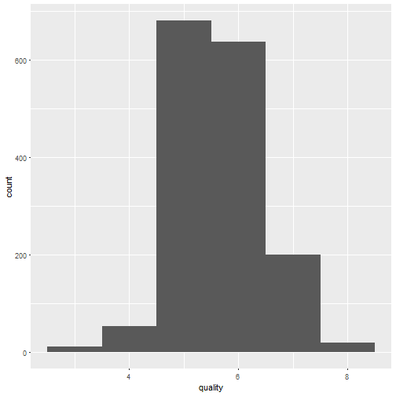

```
##    Min. 1st Qu.  Median    Mean 3rd Qu.    Max.
##   0.900   1.900   2.200   2.539   2.600  15.500
```

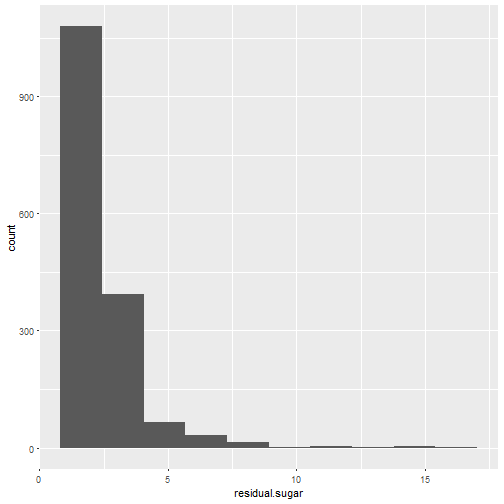

> After plotting Residual Sugar within the wines we can see that it is highly skewed to the right. Next we'll plot just the bottom 95% to get a better grasp of the distribution of residual sugars'

```
##    Min. 1st Qu.  Median    Mean 3rd Qu.    Max.
##   0.900   1.900   2.200   2.274   2.500   5.000
```

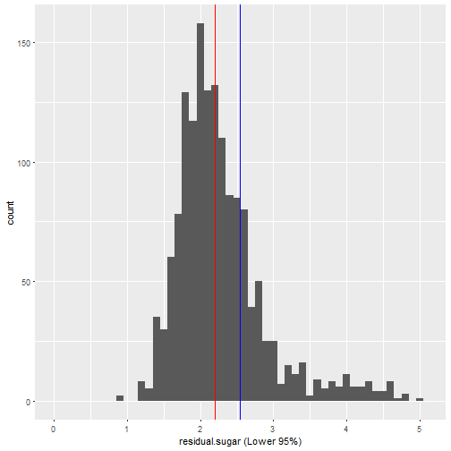

Next we will take a look at the alcohol content of each sample

```
##    Min. 1st Qu.  Median    Mean 3rd Qu.    Max.
##    8.40    9.50   10.20   10.42   11.10   14.90
```

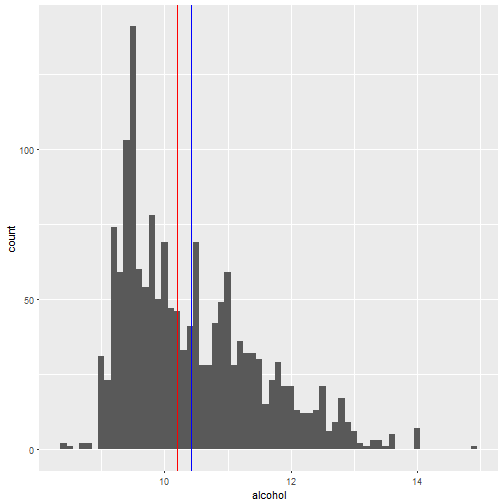

Next we'll create mutiple plots of our remaing variable and see if we see any anomolies worth exploring'

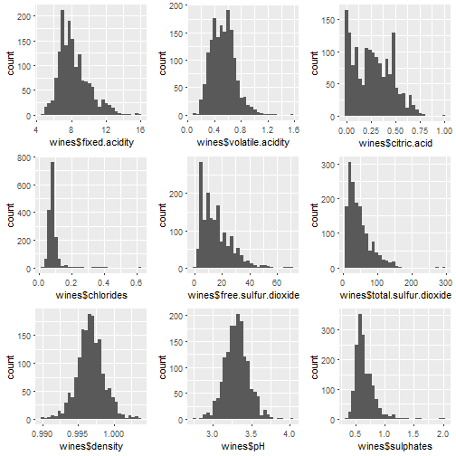

> After reviewing the plots it looks like we need to adjust the chlorides graph as it appears heavily skewed and hard to interpret in it's current raw state'.

```
##    Min. 1st Qu.  Median    Mean 3rd Qu.    Max.
## 0.01200 0.07000 0.07900 0.08747 0.09000 0.61100
```

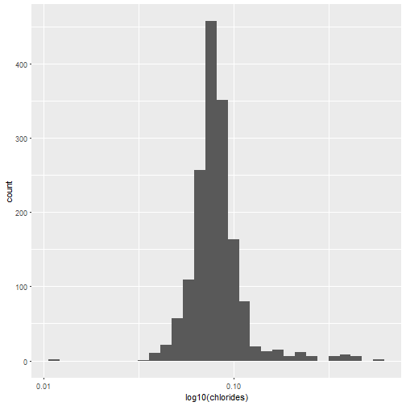

> Now that we transformed the chlorides graph into a normal distribution this will be easier for us to interpret in our analysis.

Now let's take a look at the citric acid graph. At irst take it looks like we may have a bimodal distribution so let's explore this further

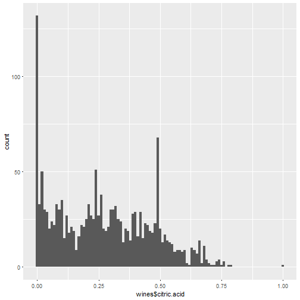

```
##
##  Hartigans' dip test for unimodality / multimodality
##
## data:  wines$citric.acid
## D = 0.025097, p-value < 2.2e-16
## alternative hypothesis: non-unimodal, i.e., at least bimodal
```

> After running a bimodal test we can see that our citric acid distribution is at least bimodal.

# Univariate Analysis

### What is the structure of your dataset?

In this data set there are 1599 observations with 12 attributes. Most of the variables are skewed distributions. With the exception of Citric Acid (bimodal) Density (normal), and pH (normal). It is rare to find a red wine with residual sugar under 1gram/liter and our data sample agrees with only one sample under 1gram/liter. Also, wines with residual sugar around 45 g/l are consider sweet. Our data set contains wines with a maximum residual sugar on 15.5 grams/liter meaning we do not have any sweet wines within our obeservations.

### What is/are the main feature(s) of interest in your dataset?

The quality variable captures my interest the most. Quality is scored between 0-10, with 0 being the worst and 10 being the best. Our data set shows a min of 3 and a max of 8. I am interested in trying to find what attributes contribute to a particular wines score.

### What other features in the dataset do you think will help support your \

investigation into your feature(s) of interest?

Considdering that we don't have any 'sweet' wines in our data set I believe that chlorides, pH, and citric acid would be the contributing factors towards a wine's' overal score.

# Bivariate Plots Section

> Next we will check the covariance between each of the variables.

```
##                      fixed.acidity volatile.acidity citric.acid
## fixed.acidity                1.000           -0.256       0.672
## volatile.acidity            -0.256            1.000      -0.552
## citric.acid                  0.672           -0.552       1.000
## residual.sugar               0.115            0.002       0.144
## chlorides                    0.094            0.061       0.204
## free.sulfur.dioxide         -0.154           -0.011      -0.061
## total.sulfur.dioxide        -0.113            0.076       0.036
## density                      0.668            0.022       0.365
## pH                          -0.683            0.235      -0.542
## sulphates                    0.183           -0.261       0.313
## alcohol                     -0.062           -0.202       0.110
## quality                      0.124           -0.391       0.226
##                      residual.sugar chlorides free.sulfur.dioxide
## fixed.acidity                 0.115     0.094              -0.154
## volatile.acidity              0.002     0.061              -0.011
## citric.acid                   0.144     0.204              -0.061
## residual.sugar                1.000     0.056               0.187
## chlorides                     0.056     1.000               0.006
## free.sulfur.dioxide           0.187     0.006               1.000
## total.sulfur.dioxide          0.203     0.047               0.668
## density                       0.355     0.201              -0.022
## pH                           -0.086    -0.265               0.070
## sulphates                     0.006     0.371               0.052
## alcohol                       0.042    -0.221              -0.069
## quality                       0.014    -0.129              -0.051
##                      total.sulfur.dioxide density     pH sulphates alcohol
## fixed.acidity                      -0.113   0.668 -0.683     0.183  -0.062
## volatile.acidity                    0.076   0.022  0.235    -0.261  -0.202
## citric.acid                         0.036   0.365 -0.542     0.313   0.110
## residual.sugar                      0.203   0.355 -0.086     0.006   0.042
## chlorides                           0.047   0.201 -0.265     0.371  -0.221
## free.sulfur.dioxide                 0.668  -0.022  0.070     0.052  -0.069
## total.sulfur.dioxide                1.000   0.071 -0.066     0.043  -0.206
## density                             0.071   1.000 -0.342     0.149  -0.496
## pH                                 -0.066  -0.342  1.000    -0.197   0.206
## sulphates                           0.043   0.149 -0.197     1.000   0.094
## alcohol                            -0.206  -0.496  0.206     0.094   1.000
## quality                            -0.185  -0.175 -0.058     0.251   0.476
##                      quality
## fixed.acidity          0.124
## volatile.acidity      -0.391
## citric.acid            0.226
## residual.sugar         0.014
## chlorides             -0.129
## free.sulfur.dioxide   -0.051
## total.sulfur.dioxide  -0.185
## density               -0.175
## pH                    -0.058
## sulphates              0.251
## alcohol                0.476
## quality                1.000
```

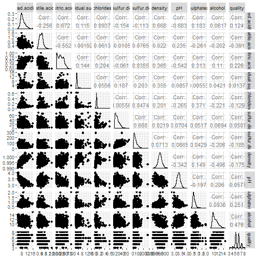

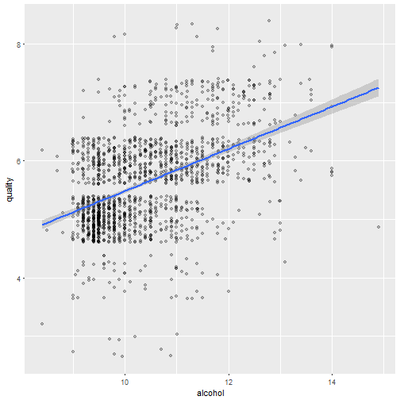

> Here we can see a positive shape to the points with our geom_smooth function pointing up and to the right. Which suggests again that alcohol content affects quality in a positive manner.

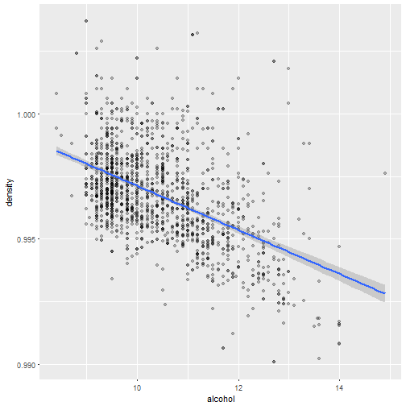

> Here we can see that the greater the alcohol the lower the density of the wine. This makes sense given that alcohol is less dense than water. Thus more alcohol would make the density fall.

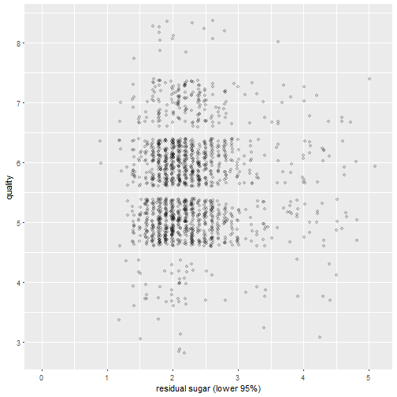

> As seen in our covariance residual sugar has almost no influence on the quality of our sample of wines. Perhaps if our study was targeted towards sweet wines we would see a correlation.

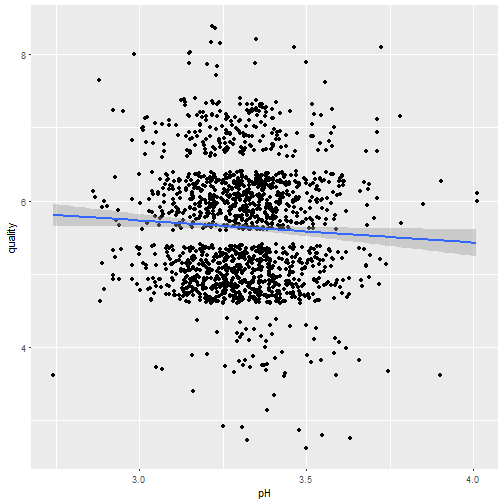

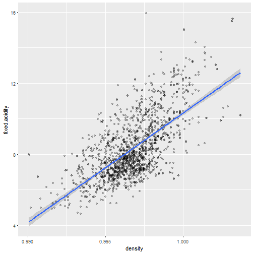

> Here we can see that fixed acidity has a highly positive correlation with density.

# Bivariate Analysis

### Talk about some of the relationships you observed in this part of the \

investigation. How did the feature(s) of interest vary with other features in \ the dataset?

I found it interesting that alcohol content had such an influence on quality score. I initially expected citric acid to be the highest contributor has it adds a freshness and flavor to the wine. We also observed that residual sugar had almost no influence on our wine scores. However, this may have been different if we were studying sweet wines.

### Did you observe any interesting relationships between the other features \

(not the main feature(s) of interest)? I found it really interesting that fixed acidity was more correlated to density than alcohol. Though alcohol negatively contributes to the density of the wine, fixed acidity positively contributed to density. This makes me curious as to what chemicals add to the acidity and how heavy those molecules are.

### What was the strongest relationship you found?

It may be no suprise but attributes that contribute to the pH value of the wine are highly correlated with eachother. I say no surprise because these factors are fixed.acidity, citric.acid, and density. The first two both directly contribute to pH but again the most surprising relationship was fixed.acidity and density.

# Multivariate Plots Section

> Next we'll' use a multivariate approach to help find prdeictive variable of quality. We'll' start plotting alcohol content vs quality and color in each point according to it's citric' acid rating. Blue dots will represent lowest quantity of citric acid while red will be the highest. A gradient function will be used to show varying degrees of citric acid present.

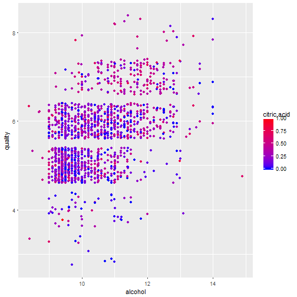

> Here a small pattern arises with higher concentrations of ctric acid in the upper right corner.

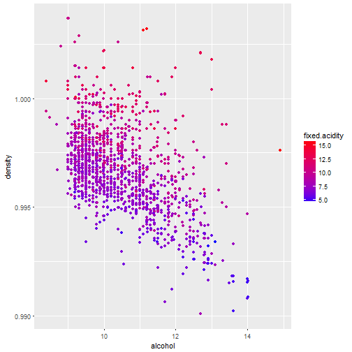

> This plot shows how alcohol content and fixed acidity have a drastic effect on the density of the wine. It appears that these two attributes counter-balance eachother. Alcohol lowers the denisty while more fixed acidity will raise the density of the wine.

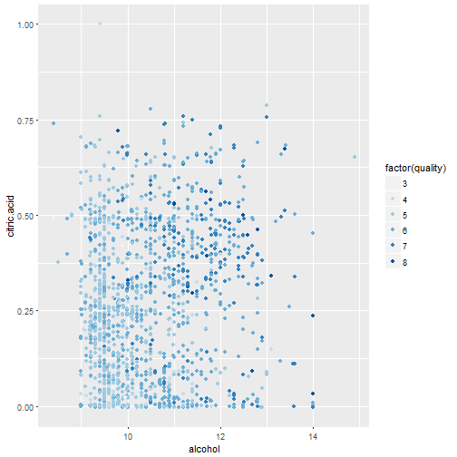

> Now when we analyze citric acid and alcohol we can see that the quality score tends towards a positive when both are present.

# Multivariate Analysis

### Talk about some of the relationships you observed in this part of the \

investigation. Were there features that strengthened each other in terms of \ looking at your feature(s) of interest?

It seems that a possibly reliable predictor is the presence of both citric acid and alcohol content. Citric acid adds freshness and flavor to the wine but this alone was not enough to raise a wine's' quality score. However, if citric acid is paired with alcohol content you could potentially produce a higher scoring wine.

### Were there any interesting or surprising interactions between features?

# Final Plots and Summary

### Plot One

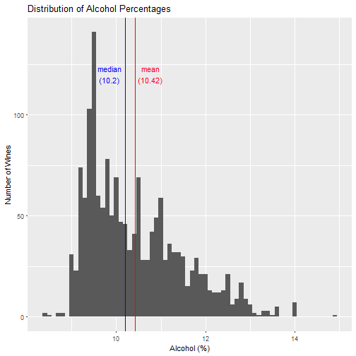

### Description One

Here we can see that the distribution of our observed wines from the data set. This distribution is a right-skewed distribution with very few wines exceeding 12% alcohol.

### Plot Two

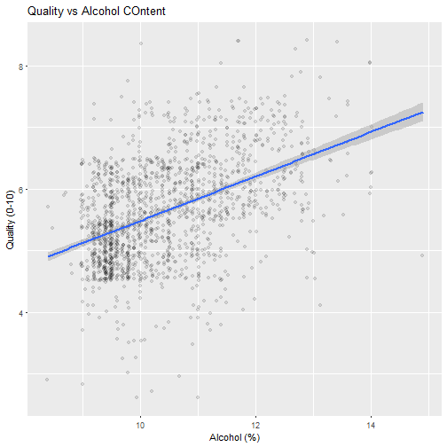

### Plot Three

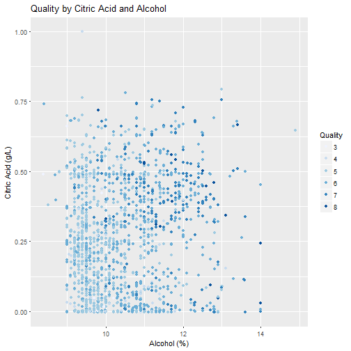

### Description Three

Citric acid adds to the wine's' flavor and tase of freshness. However, though it directly determines the wines flavor it is not enough to raise a wine's' quality score. Instead it needs a helping hand from the wine's' alcohol content to help provide a better scoring wine.

# Reflection

We were also able to see that fixed acidity correlated with density. This implies that the process that raises fixed acidity also creates a denser wine. We are unable to determine if this effects the flavor of the wine but it does counter-act the density lowering factor of the alcohol content in the wine.

A final thought is that we found that our data set consisted of rather mild red wines and did not contain any of the “sweet” varieties, wine with 45 g/l or more. Thus in our data set residual sugar was not a determining factor when analyzing our wines. In futures it would be interesting to study residual sugar in wines that are meant to be sweeter. Would more residual sugar lend to better quality wines? Or does this variable only become useful in classifying the kind of wine in the data set?